# Clustering with code

# 1. Overview

This notebook is to save all information how to do clustering with code using k-means algorithm.

# 2. Data

Same data as used to do clustering by hand - Lambeth Borough demographic data, including age and income

# 3. Preparation

Install and load libraries needed to finish it (as per Kyle’s webinar). Tidyverse

```r
library(tidyverse)
library(readr)
library(ggplot2)
```

# 4. Load data

Loading data for analysis and store them under “data” variable

```r
data <- read.csv("Clusteringdata.csv")
```

# 5. Explore and transform the data

Check if data loaded correctly using head function Rename columns Change data types to the correct one - Ward = string, Age - double, Income - integer

```r
names(data) <- c("Ward", "Age", "Income")
data$Ward <- as.character(data$Ward)
head(data)
```

|  | Ward | Age | Income |
| --- | --- | --- | --- |
| 1 | Bishop's | 35.44 | 56300 |
| 2 | Brixton Hill | 33.37 | 48400 |
| 3 | Clapham Common | 33.21 | 78300 |
| 4 | Clapham Town | 33.79 | 46500 |
| 5 | Coldharbour | 32.02 | 53400 |
| 6 | Ferndale | 33.10 | 37500 |

If the numeric data has got any other symbol (like currency), “parse” function can be used to get rid of all-numeric symbols

```r
data$Income <- parse_number(data$Income)
```

# 6. Visualise the data

This is to plot a graph that will show the data using qplot function. Other functions can be used as well like qqplot

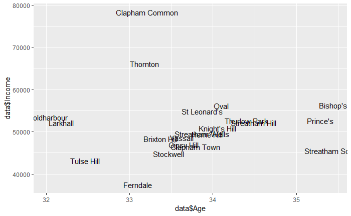

```r
qplot(x = data$Age, y = data$Income, label=data$Ward, geom = "text")
```

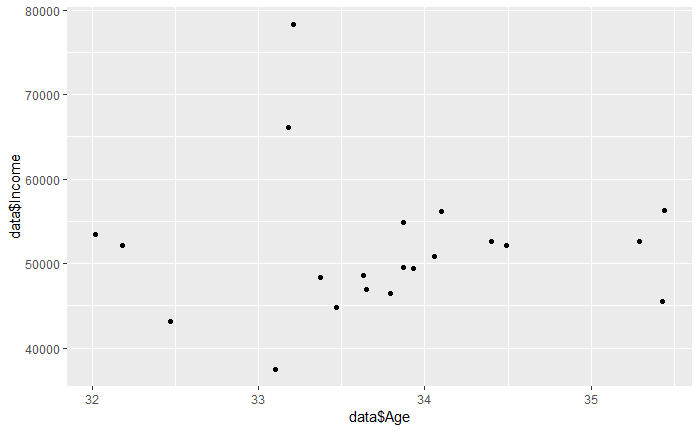

```r
ggplot(data)+
  geom_point(data = data)+
  aes(data$Age, data$Income)
```

# 7. Clustering

This is when k-means is used.

First we need to determine the number of clusters - arbitrarily it’s 3.

```r
NoClusters <- 3
```

Then we need to run k-means function to find centroids in the dataset and assign it to the new value. Each ward will be assigned to one centroid (group)

```r
kMeansResult <- kmeans(data[c("Age", "Income")], centers = NoClusters)
```

Then we will create a Cluster column in the dataset and copy values found by k-means.

```r
data$Clusters <- c(kMeansResult$cluster)
head(data)
```

|  | Ward | Age | Income | Clusters |
| --- | --- | --- | --- | --- |
| 1 | Bishop's | 35.44 | 56300 | 1 |
| 2 | Brixton Hill | 33.37 | 48400 | 1 |
| 3 | Clapham Common | 33.21 | 78300 | 3 |
| 4 | Clapham Town | 33.79 | 46500 | 2 |
| 5 | Coldharbour | 32.02 | 53400 | 1 |
| 6 | Ferndale | 33.10 | 37500 | 2 |

Then we need to convert the Clusters column to a factor

```r
data$Clusters <- as.factor(data$Clusters)
```

# 8. Visualise a cluster

To visualise a cluster, the same qplot function will be used with an additional argument - each color will represent a group as per the result of k-means

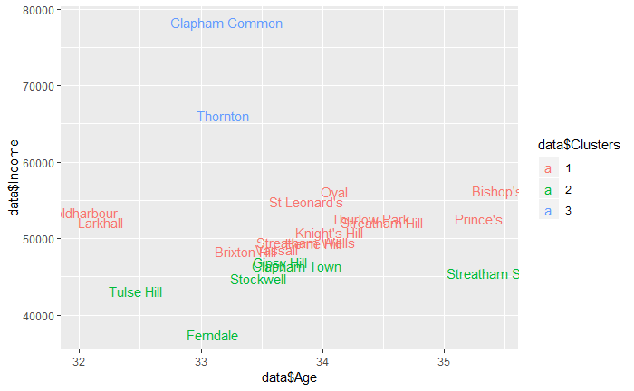

```r
qplot(x=data$Age, y=data$Income, label=data$Ward, geom = "text", color=data$Clusters)
```

# 9. (Optional) Fine tuning cluster number

Number of clusters in k-means depends on the total of within-cluster sum of squares (WSS) . The optimal number of clusters can be found by plotting a function that will show the the points for 1 to n clusters with a value of WSS. Thanks to this you can find an elbow (bend) which indicates the optimal k number.

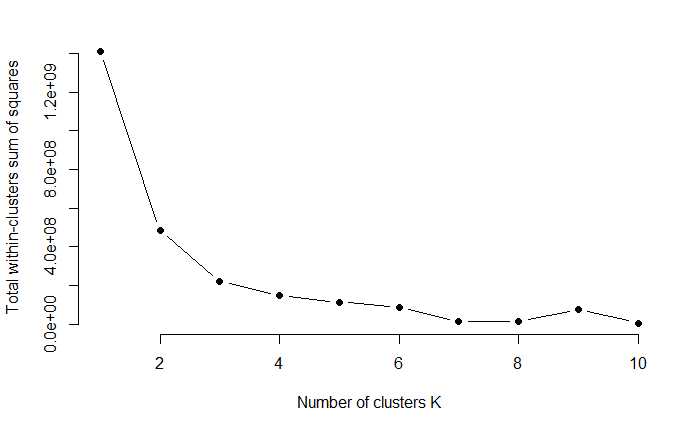

```r
kClustersMax <- 10
wss <- sapply(1:kClustersMax,
        function(k){kmeans(data[c("Age", "Income")], k)$tot.withinss})
plot(1:kClustersMax, wss,
       type="b", pch = 19, frame = FALSE,
       xlab="Number of clusters K",
       ylab="Total within-clusters sum of squares")
```

In our case the optimal value is 2 or 3 - depending on the interpretation.